# USP 634 Lab 9 - Association and Linear Regression

Jamaal Green and Liming Wang

# 1 Learning Objectives

- Review basics for analyzing data with R
- Review basics for determining which analytical technique to use with which variable types
- Learn commands for lambda, Gamma, and Pearson’s r measures of association
- Learn to do regression analysis in R
- Interpret regression outputs
- Standardized regression coefficients (beta weights)
- Download (to your RStudio project directory) and source the recode_vars.R script to recode your eb_pums dataset

# 2 Open and prepare data in R

Load the eb_pums data and recode as we’ve done before in prior labs (if feeling adventurous try to use the *source()* function to run an independent recode script).

```r
#remember to set your working director
eb_pums <- readRDS("eb_pums_2000.rds")

source("recode_vars.R")
```

# 3 Review of Basic Techniques for Analyzing Variables by Type

Some basic procedures for analyzing variables by type

- Find basic info about dataset
  - use the **summary()** function in order to get a set of basic descriptive statistics
  - use the **str()** function to see the underlying structure of your dataset including names of variables, data type etc
- Look at data case by case
  - we could simply type eb_pums into our console and have R print out the entire dataset but this is ridiculous for larger datasets. So we will pick out particular cases.
- Subset a data set
  - We can limit our the number of cases viewed by column

    `eb_pums %>% select(age, sex, racehisp)`
  - We can look at the first and last few rows of our data by using the **head()** and **tail()** functions
  - We could also look at our data using conditional statements

    `eb_pums %>% filter(sex == 2) %>% select(age, racehisp)`

    `pums.sub <- eb_pums %>% filter(racehisp %in% c("Hispanic", "Black", "Asian"))`

## 3.1 Analyze categorical (factor) variables

- Frequency distributions and bar graphs are two general categorical analysis/visualization approaches
- Contingency tables: the **xtabs** or **table** functions are commands used to analyze the relationship between two categorical variables.
- If we want to look at the columns percentages we would use the **prop.table** function
- Quick question: what is the appropriate significance test when comparing categorical variables?

## 3.2 Analyze numeric variables

- use **summary** to get basic descriptive stats
- histograms are a major tool in looking at the distribution of numeric variables
- Association (using the **cov** function) and scatterplots are our primary tools for examining the relationship between two or more numeric variables

## 3.3 Combine categorical (factor) and numeric variables

- when examining categorical and continuous variables we have to group by our categorical variables. We have multiple ways to perform group operations ranging from **tapply** functions to the *doBy* package. We’ve also covered the *dplyr* **group_by** function: `pums %>% group_by(racehisp) %>% summarize(avginc = mean(increc),medinc = median(increc))`

## 3.4 Ordinal variables

Ordinal variables fall in-between categorical and numeric variables. This particularly matters for how we treat their values in terms of analysis and visualization.

- For example, we have a survey response with a five point Likert scale (1-5). How should we examine this? Since the variable has only 5 values, the **xtabs** command may be appropriate as you can get frequency counts and percentages using the **prop.table** function. But we could also use the summary command if we were interested in say the mean responses.

# 4 Measures of Association

## 4.1 Racial/Ethnic identity and mode of work

First, what are the types of variables we’re discussing here? What sort of analysis would be appropriate?

`xtabs(~mode+racehisp, data = eb_pums, drop.unused.levels= T)` + Save xtabs results to a new object

`mode.race <- xtabs(~mode+racehisp, data = eb_pums, drop.unused.levels= T)` + Now find the percentages using **prop.table**

2. Based on these results what is the association between race and mode-to-work?
3. Now test the significance and strength of the relationship between racehisp and mode-to-work. [for this use a chi-square test]

`chisq.test(mode.race)`

4. Is the relationship statisitcally significant?
5. How strong is the relationship? Which test statistic tells you?

```r
chisq.test(mode.race)
```

```
##
##  Pearson's Chi-squared test
##
## data:  mode.race
## X-squared = 502.52, df = 15, p-value < 2.2e-16
```

```r
install.packages("vcd", repos='http://cran.us.r-project.org' )
install.packages("vcdExtra", repos = 'http://cran.us.r-project.org' )
library(vcd)
library(vcdExtra)

assocstats(mode.race)
```

```
##                     X^2 df P(> X^2)
## Likelihood Ratio 468.48 15        0
## Pearson          502.52 15        0
##
## Phi-Coefficient   : NA
## Contingency Coeff.: 0.095
## Cramer's V        : 0.055
```

```
+ What do these results indicate about the strength of the relationship?
```

## 4.2 Age of Housing and Household Income of Residents

```r
eb_pums$hinc4 <- cut(eb_pums$increc, breaks=4, labels=c("1st Quantile",
"2nd Quantile", "3rd Quantile", "4th Quantile"))
```

```r
builtyr.hinc <- xtabs(~eb_pums$builtyr2 + eb_pums$hinc4)

GKgamma(builtyr.hinc)
```

```
## gamma        : -0.174
## std. error   : 0.01
## CI           : -0.193 -0.155
```

## 4.3 Household income and commuting time

Now, consider the association between household income and commuting time. What are these two variables? What is an appropriate measure of association?

- Create a scatterplot for household income (increc) and commuting time (trantime)
- Caluclate the association between the two variables

```r
cor(eb_pums %>% select(increc, trantime), use="complete", method="pearson")
```

```
##              increc   trantime
## increc   1.00000000 0.08849303
## trantime 0.08849303 1.00000000
```

# 5 Regression

1. Research Questions: For this exercise we shall investigate the factors influencing commuting time (trantime) in the eb_pums dataset. Our dependent (response) variable is commuting time (trantime), while our independent (predictor, explanatory) variables are: increc and racehisp.
2. Explore and Plot the Data
   1. Let’s create scatterplots for trantime v. increc

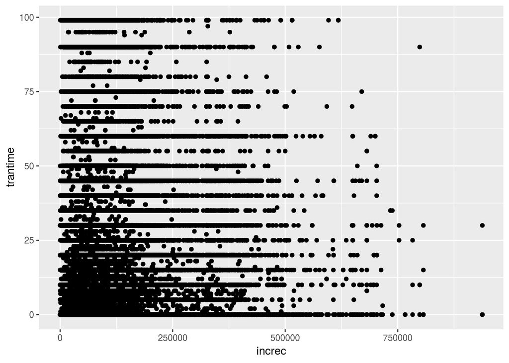

```
2. Now, let's create boxplots by groups for trantime and racehisp
```

```r
#install.packages("ggplot2", repos = "http://cran.r-project.org")
library(ggplot2)

#increc vs trantime
ggplot(eb_pums, aes(x = increc, y = trantime)) + geom_point()
```

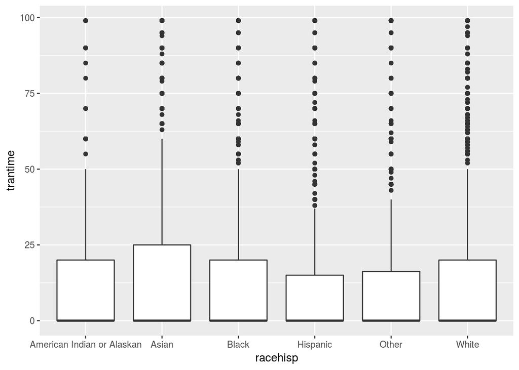

```r
#racehisp v trantime
ggplot(eb_pums, aes(x = racehisp, y = trantime)) + geom_boxplot()
```

2. Building out our model
3. Start with a univariate regression between trantime and income:

```r
#We will use the lm() function for our linear modeling

RegMod1 <- lm(trantime ~ increc, data = eb_pums)
summary(RegMod1)
```

```
##
## Call:
## lm(formula = trantime ~ increc, data = eb_pums)
##
## Residuals:
##     Min      1Q  Median      3Q     Max
## -34.733 -13.654 -12.418   7.235  86.905
##
## Coefficients:
##              Estimate Std. Error t value Pr(>|t|)
## (Intercept) 1.209e+01  9.516e-02  126.99   <2e-16 ***
## increc      2.414e-05  8.043e-07   30.02   <2e-16 ***
## ---
## Signif. codes:  0 '***' 0.001 '**' 0.01 '*' 0.05 '.' 0.1 ' ' 1
##
## Residual standard error: 21.53 on 114174 degrees of freedom
##   (3268 observations deleted due to missingness)
## Multiple R-squared:  0.007831,   Adjusted R-squared:  0.007822
## F-statistic: 901.2 on 1 and 114174 DF,  p-value: < 2.2e-16
```

What do our results tell us? Now run this again using the racehisp variable?

```r
RegMod2 <- lm(trantime ~ racehisp, data = eb_pums)
summary(RegMod2)
```

```
##
## Call:
## lm(formula = trantime ~ racehisp, data = eb_pums)
##
## Residuals:
##     Min      1Q  Median      3Q     Max
## -14.549 -14.549 -11.701   7.386  87.299
##
## Coefficients:
##                  Estimate Std. Error t value Pr(>|t|)
## (Intercept)       14.1971     0.7724  18.381  < 2e-16 ***
## racehispAsian      0.2314     0.7868   0.294  0.76866
## racehispBlack     -1.5832     0.7934  -1.995  0.04599 *
## racehispHispanic  -2.4964     0.7965  -3.134  0.00172 **
## racehispOther     -2.0892     0.8294  -2.519  0.01177 *
## racehispWhite      0.3518     0.7769   0.453  0.65070
## ---
## Signif. codes:  0 '***' 0.001 '**' 0.01 '*' 0.05 '.' 0.1 ' ' 1
##
## Residual standard error: 21.45 on 117438 degrees of freedom
## Multiple R-squared:  0.002425,   Adjusted R-squared:  0.002382
## F-statistic: 57.09 on 5 and 117438 DF,  p-value: < 2.2e-16
```

Recall that this is a so-called “fixed effects” dummy variable. How should we interpret the coefficient for our categorical variable?

3. You can try to estimate a parsimonious model with the highest adjusted $R^2$ by adding independent variables to your model

```r
finalmod <- lm(trantime ~ increc + racehisp, data = eb_pums)
summary(finalmod)
```

```
##
## Call:
## lm(formula = trantime ~ increc + racehisp, data = eb_pums)
##
## Residuals:
##     Min      1Q  Median      3Q     Max
## -34.063 -13.837 -11.751   7.582  88.560
##
## Coefficients:
##                    Estimate Std. Error t value Pr(>|t|)
## (Intercept)       1.278e+01  7.910e-01  16.152  < 2e-16 ***
## increc            2.280e-05  8.187e-07  27.844  < 2e-16 ***
## racehispAsian    -9.446e-02  8.036e-01  -0.118  0.90643
## racehispBlack    -9.502e-01  8.107e-01  -1.172  0.24121
## racehispHispanic -2.376e+00  8.132e-01  -2.922  0.00348 **
## racehispOther    -2.405e+00  8.466e-01  -2.841  0.00449 **
## racehispWhite    -1.692e-01  7.938e-01  -0.213  0.83125
## ---
## Signif. codes:  0 '***' 0.001 '**' 0.01 '*' 0.05 '.' 0.1 ' ' 1
##
## Residual standard error: 21.52 on 114169 degrees of freedom
##   (3268 observations deleted due to missingness)
## Multiple R-squared:  0.00916,    Adjusted R-squared:  0.009108
## F-statistic: 175.9 on 6 and 114169 DF,  p-value: < 2.2e-16
```

See if you can get an interaction effect between a dummy variable and a continuous variable (or another dummy variable).

4. Model Diagnostics - use the **plot()** function on your model and look at the diagnostic plots. What do they tell us about our model?
5. Finally, conduct a “reasonableness” test against initial theories/postulates and derive the policy implications.
6. Estimating regressions can answer many questions for us, such as:
   1. What is the direction of the relationship between our dependent variable and our independent variables.
   2. Are the partial slopes statistically significant? Check the t-scores and probability for each coefficient to find out
   3. You can get a confidence interval for each slope by using: `confint(finalmod)`
   4. Finally, we can determine how well are independent variables predict the values of our dependent variables. What does our $R^2$ tell us? Is it statistically significant? Check the F statistics and its probability

## 5.1 Beautify model estimation output

You can use R package such as *stargazer* and *texreg* to beautify your model estimation results

```r
install.packages("texreg", repos = "http://cran.r-project.org")
library(texreg)
screenreg(finalmod)
```

```r
# or
htmlreg(finalmod)
```

Statistical models

|  | **Model 1** |  |
| --- | --- | --- |
| (Intercept) | 12.78*** |  |
|  | (0.79) |  |
| increc | 0.00*** |  |
|  | (0.00) |  |
| racehispAsian | -0.09 |  |
|  | (0.80) |  |
| racehispBlack | -0.95 |  |
|  | (0.81) |  |
| racehispHispanic | -2.38** |  |
|  | (0.81) |  |
| racehispOther | -2.41** |  |
|  | (0.85) |  |
| racehispWhite | -0.17 |  |
|  | (0.79) |  |
| R<sup>2</sup> | 0.01 |  |
| Adj. R<sup>2</sup> | 0.01 |  |
| Num. obs. | 114176 |  |
| RMSE | 21.52 |  |
| p < 0.001, p < 0.01, p < 0.05 |  |  |

## 5.2 Beta Weights

You may wonder about the relative influence of each partial slope. To determine this, you need to convert the output to a standardized regression equation, with standardized partial slopes (aka **beta weights**). To do this we will use the *lm.beta* package.

```r
install.packages("lm.beta", repos = "http://cran.r-project.org")
library(lm.beta)

summary(lmbetamod <- lm.beta(finalmod))
```

```
##
## Call:
## lm(formula = trantime ~ increc + racehisp, data = eb_pums)
##
## Residuals:
##     Min      1Q  Median      3Q     Max
## -34.063 -13.837 -11.751   7.582  88.560
##
## Coefficients:
##                    Estimate Standardized Std. Error t value Pr(>|t|)
## (Intercept)       1.278e+01    0.000e+00  7.910e-01  16.152  < 2e-16 ***
## increc            2.280e-05    8.355e-02  8.187e-07  27.844  < 2e-16 ***
## racehispAsian    -9.446e-02   -1.657e-03  8.036e-01  -0.118  0.90643
## racehispBlack    -9.502e-01   -1.409e-02  8.107e-01  -1.172  0.24121
## racehispHispanic -2.376e+00   -3.358e-02  8.132e-01  -2.922  0.00348 **
## racehispOther    -2.405e+00   -2.258e-02  8.466e-01  -2.841  0.00449 **
## racehispWhite    -1.692e-01   -3.889e-03  7.938e-01  -0.213  0.83125
## ---
## Signif. codes:  0 '***' 0.001 '**' 0.01 '*' 0.05 '.' 0.1 ' ' 1
##
## Residual standard error: 21.52 on 114169 degrees of freedom
##   (3268 observations deleted due to missingness)
## Multiple R-squared:  0.00916,    Adjusted R-squared:  0.009108
## F-statistic: 175.9 on 6 and 114169 DF,  p-value: < 2.2e-16
```

```r
install.packages("stargazer", repos = "http://cran.r-project.org")
library(stargazer)
stargazer(finalmod, lmbetamod, column.labels=c("base", "standardized beta"),
          coef=list(finalmod$coefficients, lmbetamod$standardized.coefficients), type="html")
```

|  | *Dependent variable:* |  |
| --- | --- | --- |
|  | trantime |  |
|  | base | standardized beta |
|  | (1) | (2) |
| increc | 0.00002*** | 0.084*** |
|  | (0.00000) | (0.00000) |
| racehispAsian | -0.094 | -0.002 |
|  | (0.804) | (0.804) |
| racehispBlack | -0.950 | -0.014 |
|  | (0.811) | (0.811) |
| racehispHispanic | -2.376*** | -0.034 |
|  | (0.813) | (0.813) |
| racehispOther | -2.405*** | -0.023 |
|  | (0.847) | (0.847) |
| racehispWhite | -0.169 | -0.004 |
|  | (0.794) | (0.794) |
| Constant | 12.776*** | 0.000 |
|  | (0.791) | (0.791) |
| Observations | 114,176 | 114,176 |
| R<sup>2</sup> | 0.009 | 0.009 |
| Adjusted R<sup>2</sup> | 0.009 | 0.009 |
| Residual Std. Error (df = 114169) | 21.518 | 21.518 |
| F Statistic (df = 6; 114169) | 175.908*** | 175.908*** |
| *Note:* | p<0.1; p<0.05; p<0.01 |  |

Alternatively, if all your variables are numeric, you can first scale the variables and the re-run the regression.

Assuming a causal relationship, which independent variable exerts the most influence on trantime?